# LOCUS-MENTAL Eye Tracking Battery Validation

Iskra Todorova & Nico Bast

2026-04-22

# 1 Setup

## 1.1 Package Installation & Loading

```r
pkgs <- c(
  "tidyverse", "GGally", "lme4", "emmeans", "lmerTest",
  "dplyr", "corrplot", "factoextra", "ggpubr", "Hmisc", "kableExtra", "broom"
)

installed_packages <- pkgs %in% rownames(installed.packages())
if (any(!installed_packages)) {
  install.packages(pkgs[!installed_packages])
}

lapply(pkgs, function(pkg) {
  if (!require(pkg, character.only = TRUE, quietly = TRUE)) {
    message(paste("Package", pkg, "could not be loaded."))
  }
})
```

## 1.2 File Paths

```r
home_path      <- "S:/KJP_Studien"
data_path_vo   <- "/LOCUS_MENTAL/6_Versuchsdaten/visual_oddball/"
data_path_ao   <- "/LOCUS_MENTAL/6_Versuchsdaten/auditory_oddball/"
data_path_rss  <- "/LOCUS_MENTAL/6_Versuchsdaten/rapid_sound_sequences/"
data_path_cvs  <- "/LOCUS_MENTAL/6_Versuchsdaten/visual_search_task/"
demo_data_path <- "S:/KJP_Studien/LOCUS_MENTAL/6_Versuchsdaten/"
```

# 2 Data Loading

```r
# Aggregated task data
df_ao  <- readRDS(paste0(home_path, data_path_ao,  "df_sepr_aggregated_AO.rds"))
df_vo  <- readRDS(paste0(home_path, data_path_vo,  "sepr_condition.rds"))
df_rss <- readRDS(paste0(home_path, data_path_rss, "df_sepr_aggregated_RSS.rds"))
df_cvs <- readRDS(paste0(home_path, data_path_cvs, "df_cued_agg.rds"))

# Baseline pupil size (BPS) trial-level data
bps_rss <- readRDS(paste0(home_path, data_path_rss, "bps_data.rds"))
bps_ao  <- readRDS(paste0(home_path, data_path_ao,  "bps_data.rds"))
bps_cvs <- readRDS(paste0(home_path, data_path_cvs, "bps_data.rds"))

# Demographic data
load(file.path(demo_data_path, "demo_data.rda"))
demo_data <- data
```

# 3 Data Preparation

Each task dataset is cleaned and standardised before being joined into a single master dataframe.

## 3.1 Auditory Oddball (AO)

```r
data_ao <- df_ao %>%
  select(id, SEPR_AO_m_oddball, SEPR_AO_m_standard, BPS_oddball, BPS_standard) %>%
  rename(
    BPS_AO_standard = BPS_standard,
    BPS_AO_oddball  = BPS_oddball
  ) %>%
  mutate(
    SEPR_AO_standard_z = as.numeric(scale(SEPR_AO_m_standard)),
    SEPR_AO_oddball_z  = as.numeric(scale(SEPR_AO_m_oddball))
  )
```

## 3.2 Rapid Sound Sequences (RSS)

```r
data_rss <- df_rss %>%
  select(
    id,
    RSS_SEPR_early_mean_control, RSS_SEPR_early_mean_transition,
    RSS_BPS_mean_control, RSS_BPS_mean_transition,
    mean_diff_RAND_to_REG1, mean_diff_REG_to_RAND, mean_diff_RAND_to_REG10
  ) %>%
  rename(
    BPR_RSS_control    = RSS_BPS_mean_control,
    BPS_RSS_transition = RSS_BPS_mean_transition
  ) %>%
  mutate(
    RSS_transition_z = as.numeric(scale(RSS_SEPR_early_mean_transition)),
    RSS_control_z    = as.numeric(scale(RSS_SEPR_early_mean_control))
  )
```

## 3.3 Visual Oddball (VO)

```r
# Pivot from long to wide; retain only participants with >= 7 trials in both conditions
data_vo <- df_vo %>%
  filter(n_trials >= 7) %>%
  group_by(id) %>%
  filter(n() == 2) %>%
  ungroup() %>%
  mutate(sepr_scaled = as.numeric(scale(sepr_mean))) %>%
  select(id, condition, sepr_mean, sepr_scaled, BPS, n_trials) %>%
  pivot_wider(
    names_from  = condition,
    values_from = c(sepr_mean, sepr_scaled, BPS, n_trials),
    names_glue  = "{.value}_VO_{condition}"
  )

cat("Participants remaining in VO task:", nrow(data_vo), "\n")
```

```
## Participants remaining in VO task: 74
```

## 3.4 Cued Visual Search (CVS)

```r
data_cvs <- df_cvs %>%
  select(
    id,
    CEPR_CUED_mean_cued, CEPR_CUED_mean_standard,
    SEPR_mean_cued, SEPR_mean_standard,
    BPS_cued, BPS_standard
  )
```

## 3.5 Master Dataframe

```r
# Full join retains all participants; missing tasks appear as NAs.
# VO excluded pending data structure harmonisation — see note above.
df_final <- data_ao %>%
  full_join(data_rss, by = "id") %>%
  # full_join(data_vo, by = "id") %>%
  full_join(data_cvs, by = "id")

cat("Total participants in master dataframe:", nrow(df_final), "\n")
```

[output not shown]

```
## Total participants in master dataframe: 99
```

# 4 Baseline Pupil Size (BPS)

BPS reflects individual differences in tonic arousal and is expected to be highly stable within a person across tasks.

## 4.1 Within-Battery Consistency

```r
bps_matrix <- df_final %>% select(id, starts_with("BPS"))

cor_bps <- cor(
  bps_matrix %>% select(-id),
  use    = "pairwise.complete.obs",
  method = "spearman"
)

cat("Spearman Correlations of Baseline Pupil Size Across Tasks:\n")
```

```
## Spearman Correlations of Baseline Pupil Size Across Tasks:
```

```r
print(round(cor_bps, 2))
```

```
##                    BPS_AO_oddball BPS_AO_standard BPS_RSS_transition BPS_cued
## BPS_AO_oddball               1.00            0.99               0.88     0.86
## BPS_AO_standard              0.99            1.00               0.90     0.88
## BPS_RSS_transition           0.88            0.90               1.00     0.92
## BPS_cued                     0.86            0.88               0.92     1.00
## BPS_standard                 0.87            0.88               0.92     0.97
##                    BPS_standard
## BPS_AO_oddball             0.87
## BPS_AO_standard            0.88
## BPS_RSS_transition         0.92
## BPS_cued                   0.97
## BPS_standard               1.00
```

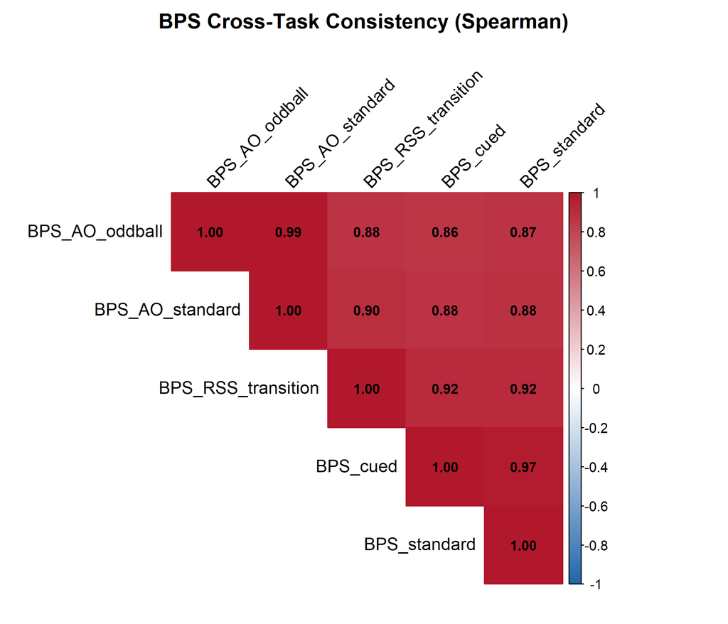

```r
corrplot(
  cor_bps,
  method      = "color",
  type        = "upper",
  tl.col      = "black",
  tl.srt      = 45,
  addCoef.col = "black",
  number.cex  = 0.8,
  col         = colorRampPalette(c("#2166AC", "white", "#B2182B"))(200),
  title       = "BPS Cross-Task Consistency (Spearman)",
  mar         = c(0, 0, 2, 0)
)
```

## 4.2 BPS Descriptive Summary

```r
bps_summary <- data.frame(
  Task     = c("AO", "RSS", "CVS"),
  Mean_BPS = c(
    mean(df_final$BPS_AO_standard,    na.rm = TRUE),
    mean(df_final$BPS_RSS_transition, na.rm = TRUE),
    mean(df_final$BPS_cued,           na.rm = TRUE)
  ),
  SD_BPS = c(
    sd(df_final$BPS_AO_standard,    na.rm = TRUE),
    sd(df_final$BPS_RSS_transition, na.rm = TRUE),
    sd(df_final$BPS_cued,           na.rm = TRUE)
  )
)

bps_summary %>%
  mutate(across(where(is.numeric), ~ round(.x, 3))) %>%
  kable(caption = "Mean Baseline Pupil Size (mm) per Task") %>%
  kable_styling(bootstrap_options = c("striped", "hover"), full_width = FALSE)
```

Mean Baseline Pupil Size (mm) per Task

| Task | Mean_BPS | SD_BPS |
| --- | --- | --- |
| AO | 3.642 | 0.471 |
| RSS | 3.629 | 0.429 |
| CVS | 3.491 | 0.410 |

# 5 Habituation Analysis

Mixed-effects models test whether BPS drifts systematically over the course of each task. Expectation: negative estimates

## 5.1 BPS Trajectory Plots

Trial-by-trial mean BPS for each task. A downward trend indicates habituation; a flat profile indicates stable arousal across the session.

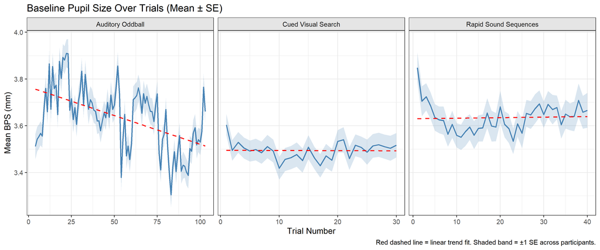

```r
# AO
ao_traj <- bps_ao %>%
  group_by(trial_number) %>%
  summarise(mean_BPS = mean(BPS, na.rm = TRUE),
            se_BPS   = sd(BPS, na.rm = TRUE) / sqrt(n()),
            .groups  = "drop") %>%
  mutate(Task = "Auditory Oddball")

# CVS
cvs_traj <- bps_cvs %>%
  group_by(trial_number) %>%
  summarise(mean_BPS = mean(BPS, na.rm = TRUE),
            se_BPS   = sd(BPS, na.rm = TRUE) / sqrt(n()),
            .groups  = "drop") %>%
  mutate(Task = "Cued Visual Search")

# RSS
rss_traj <- bps_rss %>%
  rename(trial_number = Trial.Number) %>%
  group_by(trial_number) %>%
  summarise(mean_BPS = mean(BPS, na.rm = TRUE),
            se_BPS   = sd(BPS, na.rm = TRUE) / sqrt(n()),
            .groups  = "drop") %>%
  mutate(Task = "Rapid Sound Sequences")

bind_rows(ao_traj, cvs_traj, rss_traj) %>%
  ggplot(aes(x = trial_number, y = mean_BPS)) +
  geom_ribbon(aes(ymin = mean_BPS - se_BPS, ymax = mean_BPS + se_BPS),
              fill = "steelblue", alpha = 0.2) +
  geom_line(colour = "steelblue", linewidth = 0.8) +
  geom_smooth(method = "lm", colour = "red", linetype = "dashed",
              linewidth = 0.7, se = FALSE) +
  facet_wrap(~ Task, scales = "free_x") +
  labs(
    title   = "Baseline Pupil Size Over Trials (Mean ± SE)",
    x       = "Trial Number",
    y       = "Mean BPS (mm)",
    caption = "Red dashed line = linear trend fit. Shaded band = ±1 SE across participants."
  ) +
  theme_bw(base_size = 12) +
  theme(strip.background = element_rect(fill = "grey90"))
```

## 5.2 Auditory Oddball

```r
bps_ao$condition <- as.factor(bps_ao$condition)

m_ao_hab <- lmer(BPS ~ trial_number + (1 | id), data = bps_ao)
cat("--- AO: Main effect of trial number ---\n")
```

```
## --- AO: Main effect of trial number ---
```

```r
print(anova(m_ao_hab))
```

```
## Type III Analysis of Variance Table with Satterthwaite's method
##              Sum Sq Mean Sq NumDF  DenDF F value    Pr(>F)
## trial_number 47.073  47.073     1 9215.4  600.02 < 2.2e-16 ***
## ---
## Signif. codes:  0 '***' 0.001 '**' 0.01 '*' 0.05 '.' 0.1 ' ' 1
```

```r
m_ao_int <- lmer(BPS ~ trial_number * condition + (1 | id), data = bps_ao)
cat("--- AO: Trial number x Condition interaction ---\n")
```

```
## --- AO: Trial number x Condition interaction ---
```

```r
print(anova(m_ao_int))
```

```
## Type III Analysis of Variance Table with Satterthwaite's method
##                         Sum Sq Mean Sq NumDF  DenDF  F value Pr(>F)
## trial_number           31.2103 31.2103     1 9213.3 397.7901 <2e-16 ***
## condition               0.0732  0.0732     1 9213.0   0.9331 0.3341
## trial_number:condition  0.0322  0.0322     1 9213.0   0.4110 0.5215
## ---
## Signif. codes:  0 '***' 0.001 '**' 0.01 '*' 0.05 '.' 0.1 ' ' 1
```

## 5.3 Cued Visual Search

```r
bps_cvs$Condition    <- as.factor(bps_cvs$Condition)
bps_cvs$trial_number <- as.numeric(bps_cvs$trial_number)

m_cvs_hab <- lmer(BPS ~ trial_number + (1 | id), data = bps_cvs)
cat("--- CVS: Main effect of trial number ---\n")
```

```
## --- CVS: Main effect of trial number ---
```

```r
print(anova(m_cvs_hab))
```

```
## Type III Analysis of Variance Table with Satterthwaite's method
##                 Sum Sq   Mean Sq NumDF  DenDF F value Pr(>F)
## trial_number 0.0088373 0.0088373     1 2768.5  0.1478 0.7007
```

```r
m_cvs_int <- lmer(BPS ~ trial_number * Condition + (1 | id), data = bps_cvs)
cat("--- CVS: Trial number x Condition interaction ---\n")
```

```
## --- CVS: Trial number x Condition interaction ---
```

```r
print(anova(m_cvs_int))
```

```
## Type III Analysis of Variance Table with Satterthwaite's method
##                           Sum Sq   Mean Sq NumDF  DenDF F value Pr(>F)
## trial_number           0.0098614 0.0098614     1 2766.5  0.1648 0.6848
## Condition              0.0184609 0.0184609     1 2767.9  0.3085 0.5786
## trial_number:Condition 0.0215491 0.0215491     1 2767.6  0.3601 0.5485
```

## 5.4 Rapid Sound Sequences

```r
bps_rss$Condition    <- as.factor(bps_rss$Condition)
bps_rss$Trial.Number <- as.numeric(bps_rss$Trial.Number)

m_rss_hab <- lmer(BPS ~ Trial.Number + (1 | id), data = bps_rss)
cat("--- RSS: Main effect of trial number ---\n")
```

```
## --- RSS: Main effect of trial number ---
```

```r
print(anova(m_rss_hab))
```

```
## Type III Analysis of Variance Table with Satterthwaite's method
##               Sum Sq Mean Sq NumDF  DenDF F value Pr(>F)
## Trial.Number 0.04496 0.04496     1 2566.4  0.7323 0.3922
```

```r
m_rss_int <- lmer(BPS ~ Trial.Number * Condition + (1 | id), data = bps_rss)
cat("--- RSS: Trial number x Condition interaction ---\n")
```

```
## --- RSS: Trial number x Condition interaction ---
```

```r
print(anova(m_rss_int))
```

```
## Type III Analysis of Variance Table with Satterthwaite's method
##                          Sum Sq  Mean Sq NumDF  DenDF F value Pr(>F)
## Trial.Number           0.014101 0.014101     1 2558.5  0.2293 0.6321
## Condition              0.147199 0.036800     4 2558.0  0.5985 0.6638
## Trial.Number:Condition 0.085415 0.021354     4 2558.3  0.3473 0.8461
```

# 6 Correlation Analysis

> **Method note:** Spearman rank correlations are used throughout as the primary measure, as pupil dilation data may deviate from normality.

## 6.1 Build Correlation Dataset

```r
df_cor_rpd_raw <- df_final %>%
  select(
    id,
    SEPR_AO_m_oddball, SEPR_AO_m_standard,                                  # AO
    RSS_SEPR_early_mean_control, RSS_SEPR_early_mean_transition,             # RSS SEPR
    mean_diff_RAND_to_REG1, mean_diff_REG_to_RAND, mean_diff_RAND_to_REG10, # RSS diffs
    SEPR_mean_cued, SEPR_mean_standard,                                      # CVS SEPR
    CEPR_CUED_mean_cued, CEPR_CUED_mean_standard                             # CVS CEPR
  )

cat("N participants in correlation dataset:", nrow(df_cor_rpd_raw), "\n")
```

```
## N participants in correlation dataset: 99
```

## 6.2 Spearman Correlation Matrix with FDR-Corrected p-values

`Hmisc::rcorr()` computes r and p simultaneously. p-values are then corrected for multiple comparisons using the Benjamini-Hochberg (FDR) procedure.

```r
cor_obj <- Hmisc::rcorr(
  as.matrix(df_cor_rpd_raw %>% select(-id)),
  type = "spearman"
)

r_mat <- cor_obj$r
p_mat <- cor_obj$P

# Apply BH-FDR correction to all upper-triangle p-values
p_fdr_mat <- matrix(NA, nrow = nrow(p_mat), ncol = ncol(p_mat),
                    dimnames = dimnames(p_mat))
p_fdr_vec <- p.adjust(p_mat[upper.tri(p_mat)], method = "BH")
p_fdr_mat[upper.tri(p_fdr_mat)] <- p_fdr_vec
p_fdr_mat[lower.tri(p_fdr_mat)] <- t(p_fdr_mat)[lower.tri(p_fdr_mat)]
diag(p_fdr_mat)                 <- 1  # diagonal has no p-value; set to 1 so corrplot ignores it

cat("Spearman r matrix:\n")
```

```
## Spearman r matrix:
```

```r
print(round(r_mat, 2))
```

```
##                                SEPR_AO_m_oddball SEPR_AO_m_standard
## SEPR_AO_m_oddball                           1.00              -0.06
## SEPR_AO_m_standard                         -0.06               1.00
## RSS_SEPR_early_mean_control                 0.00               0.15
## RSS_SEPR_early_mean_transition              0.05               0.06
## mean_diff_RAND_to_REG1                     -0.14               0.05
## mean_diff_REG_to_RAND                       0.12              -0.11
## mean_diff_RAND_to_REG10                    -0.19              -0.02
## SEPR_mean_cued                             -0.12               0.17
## SEPR_mean_standard                         -0.17               0.03
## CEPR_CUED_mean_cued                        -0.15               0.16
## CEPR_CUED_mean_standard                    -0.10              -0.01
##                                RSS_SEPR_early_mean_control
## SEPR_AO_m_oddball                                     0.00
## SEPR_AO_m_standard                                    0.15
## RSS_SEPR_early_mean_control                           1.00
## RSS_SEPR_early_mean_transition                        0.01
## mean_diff_RAND_to_REG1                               -0.41
## mean_diff_REG_to_RAND                                -0.37
## mean_diff_RAND_to_REG10                              -0.50
## SEPR_mean_cued                                       -0.04
## SEPR_mean_standard                                    0.05
## CEPR_CUED_mean_cued                                   0.10
## CEPR_CUED_mean_standard                               0.16
##                                RSS_SEPR_early_mean_transition
## SEPR_AO_m_oddball                                        0.05
## SEPR_AO_m_standard                                       0.06
## RSS_SEPR_early_mean_control                              0.01
## RSS_SEPR_early_mean_transition                           1.00
## mean_diff_RAND_to_REG1                                   0.44
## mean_diff_REG_to_RAND                                    0.32
## mean_diff_RAND_to_REG10                                  0.30
## SEPR_mean_cued                                           0.00
## SEPR_mean_standard                                       0.02
## CEPR_CUED_mean_cued                                      0.07
## CEPR_CUED_mean_standard                                 -0.08
##                                mean_diff_RAND_to_REG1 mean_diff_REG_to_RAND
## SEPR_AO_m_oddball                               -0.14                  0.12
## SEPR_AO_m_standard                               0.05                 -0.11
## RSS_SEPR_early_mean_control                     -0.41                 -0.37
```

[output cut: 29 more lines]

```
## SEPR_mean_standard                           1.00                0.07
## CEPR_CUED_mean_cued                          0.07                1.00
## CEPR_CUED_mean_standard                      0.28                0.22
##                                CEPR_CUED_mean_standard
## SEPR_AO_m_oddball                                -0.10
## SEPR_AO_m_standard                               -0.01
## RSS_SEPR_early_mean_control                       0.16
## RSS_SEPR_early_mean_transition                   -0.08
## mean_diff_RAND_to_REG1                           -0.10
## mean_diff_REG_to_RAND                            -0.01
## mean_diff_RAND_to_REG10                          -0.14
## SEPR_mean_cued                                    0.16
## SEPR_mean_standard                                0.28
## CEPR_CUED_mean_cued                               0.22
## CEPR_CUED_mean_standard                           1.00
```

```r
cat("\nFDR-corrected p-value matrix (BH):\n")
```

```
##
## FDR-corrected p-value matrix (BH):
```

```r
print(round(p_fdr_mat, 3))
```

```
##                                SEPR_AO_m_oddball SEPR_AO_m_standard
## SEPR_AO_m_oddball                          1.000              0.755
## SEPR_AO_m_standard                         0.755              1.000
## RSS_SEPR_early_mean_control                0.994              0.476
## RSS_SEPR_early_mean_transition             0.851              0.833
## mean_diff_RAND_to_REG1                     0.490              0.833
## mean_diff_REG_to_RAND                      0.562              0.591
## mean_diff_RAND_to_REG10                    0.356              0.968
## SEPR_mean_cued                             0.514              0.356
## SEPR_mean_standard                         0.356              0.945
## CEPR_CUED_mean_cued                        0.445              0.388
## CEPR_CUED_mean_standard                    0.591              0.968
##                                RSS_SEPR_early_mean_control
## SEPR_AO_m_oddball                                    0.994
## SEPR_AO_m_standard                                   0.476
## RSS_SEPR_early_mean_control                          1.000
## RSS_SEPR_early_mean_transition                       0.984
## mean_diff_RAND_to_REG1                               0.001
## mean_diff_REG_to_RAND                                0.006
## mean_diff_RAND_to_REG10                              0.000
## SEPR_mean_cued                                       0.856
## SEPR_mean_standard                                   0.833
## CEPR_CUED_mean_cued                                  0.591
## CEPR_CUED_mean_standard                              0.446
##                                RSS_SEPR_early_mean_transition
## SEPR_AO_m_oddball                                       0.851
## SEPR_AO_m_standard                                      0.833
## RSS_SEPR_early_mean_control                             0.984
## RSS_SEPR_early_mean_transition                          1.000
## mean_diff_RAND_to_REG1                                  0.001
## mean_diff_REG_to_RAND                                   0.029
## mean_diff_RAND_to_REG10                                 0.039
## SEPR_mean_cued                                          0.994
## SEPR_mean_standard                                      0.968
## CEPR_CUED_mean_cued                                     0.755
## CEPR_CUED_mean_standard                                 0.744
##                                mean_diff_RAND_to_REG1 mean_diff_REG_to_RAND
## SEPR_AO_m_oddball                               0.490                 0.562
## SEPR_AO_m_standard                              0.833                 0.591
## RSS_SEPR_early_mean_control                     0.001                 0.006
```

[output cut: 29 more lines]

```
## SEPR_mean_standard                          1.000               0.733
## CEPR_CUED_mean_cued                         0.733               1.000
## CEPR_CUED_mean_standard                     0.029               0.139
##                                CEPR_CUED_mean_standard
## SEPR_AO_m_oddball                                0.591
## SEPR_AO_m_standard                               0.968
## RSS_SEPR_early_mean_control                      0.446
## RSS_SEPR_early_mean_transition                   0.744
## mean_diff_RAND_to_REG1                           0.591
## mean_diff_REG_to_RAND                            0.968
## mean_diff_RAND_to_REG10                          0.490
## SEPR_mean_cued                                   0.388
## SEPR_mean_standard                               0.029
## CEPR_CUED_mean_cued                              0.139
## CEPR_CUED_mean_standard                          1.000
```

[figure not shown]

```r
# 1. Get the number of variables to help with positioning
n <- ncol(r_mat)

# 2. Run corrplot WITHOUT addCoef.col
corrplot(
  r_mat,
  method      = "color",
  type        = "upper",
  tl.col      = "black",
  tl.srt      = 45,
  tl.cex      = 0.8,
  addCoef.col = NULL,      # Change this to NULL to stop the overlap
  p.mat       = p_fdr_mat,
  sig.level   = 0.05,
  insig       = "pch",
  pch         = 8,
  pch.cex     = 1.2,      # Slightly smaller stars help readability
  pch.col     = "black",
  col         = colorRampPalette(c("#2166AC", "white", "#B2182B"))(200),
  title       = "Spearman Correlations (stars = FDR p < .05)",
  mar         = c(0, 0, 2, 0)
)

# 3. Manually add the coefficients with a slight downward offset
# This loops through the upper triangle (where column j > row i)
for (i in 1:(n-1)) {
  for (j in (i+1):n) {
    # x is the column (j), y is the row (reversed for corrplot: n - i + 1)
    # We use 'pos = 1' to place the text directly below the center point
    text(x = j,
         y = n - i + 1,
         labels = round(r_mat[i, j], 2),
         pos = 1,       # pos=1 puts text BELOW the center; pos=3 puts it ABOVE
         offset = 0.6,  # adjust this number to move the text further up or down
         cex = 0.6,
         col = "black")
  }
}
```

## 6.3 Significant Correlation Pairs (FDR p < .05)

```r
vars <- colnames(r_mat)

data.frame(
  Var1  = vars[row(r_mat)[upper.tri(r_mat)]],
  Var2  = vars[col(r_mat)[upper.tri(r_mat)]],
  r     = round(r_mat[upper.tri(r_mat)], 3),
  p_fdr = round(p_fdr_mat[upper.tri(p_fdr_mat)], 4)
) %>%
  filter(p_fdr < 0.05) %>%
  arrange(p_fdr) %>%
  kable(caption = "Significant Spearman Correlations (FDR-corrected p < .05)") %>%
  kable_styling(bootstrap_options = c("striped", "hover"), full_width = FALSE)
```

Significant Spearman Correlations (FDR-corrected p < .05)

| Var1 | Var2 | r | p_fdr |
| --- | --- | --- | --- |
| RSS_SEPR_early_mean_control | mean_diff_RAND_to_REG10 | -0.504 | 0.0000 |
| mean_diff_RAND_to_REG1 | mean_diff_RAND_to_REG10 | 0.552 | 0.0000 |
| SEPR_mean_cued | SEPR_mean_standard | 0.564 | 0.0000 |
| RSS_SEPR_early_mean_transition | mean_diff_RAND_to_REG1 | 0.440 | 0.0008 |
| SEPR_mean_cued | CEPR_CUED_mean_cued | 0.392 | 0.0008 |
| RSS_SEPR_early_mean_control | mean_diff_RAND_to_REG1 | -0.415 | 0.0015 |
| RSS_SEPR_early_mean_control | mean_diff_REG_to_RAND | -0.372 | 0.0063 |
| RSS_SEPR_early_mean_transition | mean_diff_REG_to_RAND | 0.318 | 0.0285 |
| SEPR_mean_standard | CEPR_CUED_mean_standard | 0.285 | 0.0285 |
| RSS_SEPR_early_mean_transition | mean_diff_RAND_to_REG10 | 0.302 | 0.0391 |

## 6.4 Pairwise Scatter Plot Matrix (GGally)

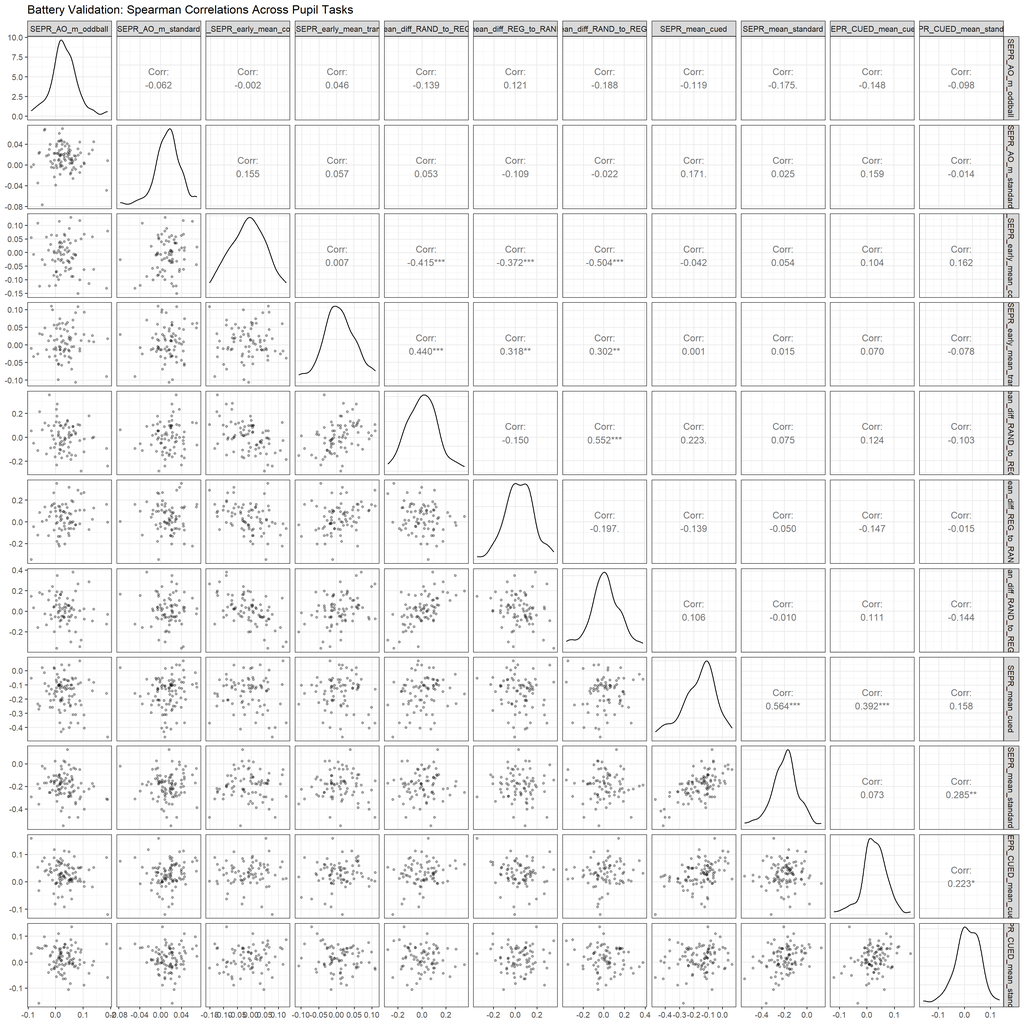

```r
ggpairs(
  df_cor_rpd_raw %>% select(-id),
  columns = 1:(ncol(df_cor_rpd_raw) - 1),
  upper   = list(continuous = wrap("cor", method = "spearman", size = 3)),
  lower   = list(continuous = wrap("points", alpha = 0.3, size = 0.8)),
  diag    = list(continuous = wrap("densityDiag"))
) +
  theme_bw(base_size = 9) +
  labs(title = "Battery Validation: Spearman Correlations Across Pupil Tasks")
```

## 6.5 Cross-Task Summary: Primary Condition Means

The most direct test of convergent validity: Spearman correlations between the single primary outcome from each task (AO Oddball, RSS Transition, CVS Cued).

```r
cross_task_cor <- df_final %>%
  select(
    AO_Oddball     = SEPR_AO_m_oddball,
    RSS_Transition = RSS_SEPR_early_mean_transition,
    Cued_Task      = CEPR_CUED_mean_cued
  ) %>%
  as.matrix() %>%
  Hmisc::rcorr(type = "spearman")

cat("Cross-task r:\n")
```

```
## Cross-task r:
```

```r
print(round(cross_task_cor$r, 2))
```

```
##                AO_Oddball RSS_Transition Cued_Task
## AO_Oddball           1.00           0.05     -0.15
## RSS_Transition       0.05           1.00      0.07
## Cued_Task           -0.15           0.07      1.00
```

```r
cat("\nCross-task p (uncorrected — only 3 pairs):\n")
```

```
##
## Cross-task p (uncorrected — only 3 pairs):
```

```r
print(round(cross_task_cor$P, 3))
```

```
##                AO_Oddball RSS_Transition Cued_Task
## AO_Oddball             NA          0.696     0.154
## RSS_Transition      0.696             NA     0.547
## Cued_Task           0.154          0.547        NA
```

# 7 Principal Component Analysis (PCA)

PCA summarises the shared variance structure across all task conditions and helps identify whether tasks cluster into interpretable groups or measure largely independent processes.

## 7.1 Run PCA

```r
pca_data       <- df_cor_rpd_raw[, 2:ncol(df_cor_rpd_raw)]
pca_data_clean <- na.omit(pca_data)

cat("N entering PCA (complete cases):", nrow(pca_data_clean),
    "of", nrow(pca_data), "total\n")
```

```
## N entering PCA (complete cases): 74 of 99 total
```

```r
pca_result <- prcomp(pca_data_clean, center = TRUE, scale. = TRUE)
```

## 7.2 Scree Plot

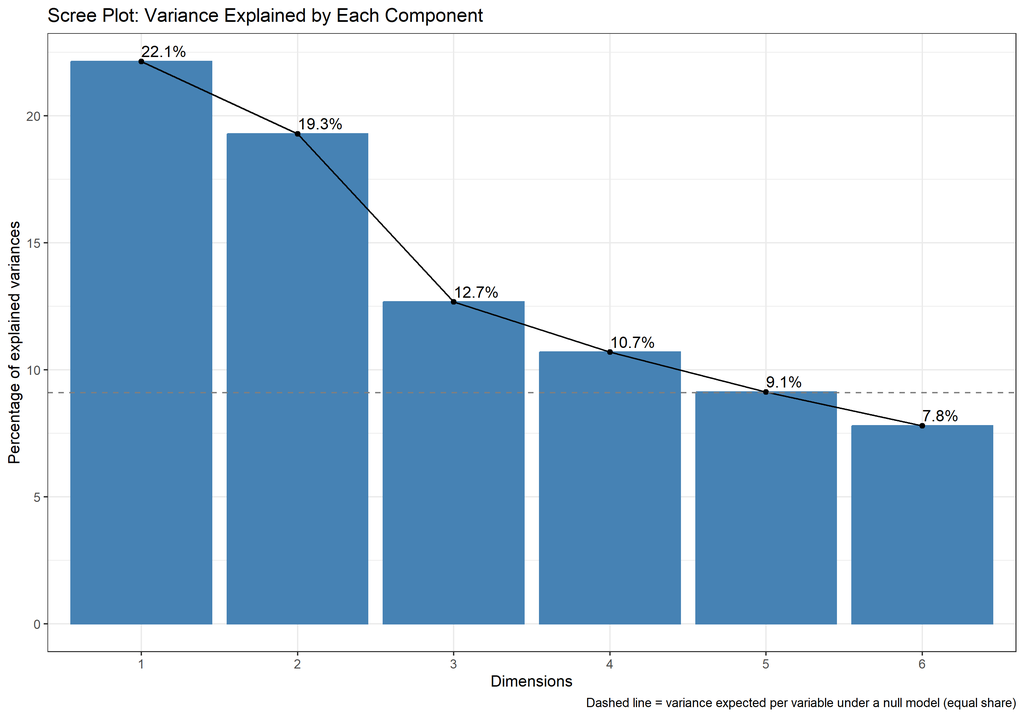

```r
fviz_eig(pca_result, addlabels = TRUE, ncp = 6) +
  geom_hline(yintercept = 100 / ncol(pca_data_clean),
             linetype = "dashed", colour = "grey50") +
  labs(
    title   = "Scree Plot: Variance Explained by Each Component",
    caption = "Dashed line = variance expected per variable under a null model (equal share)"
  ) +
  theme_bw()
```

## 7.3 Variable Factor Map

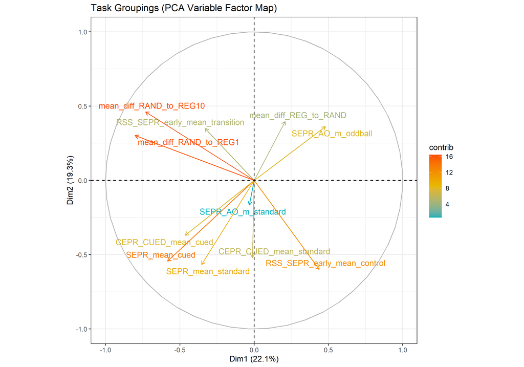

```r
fviz_pca_var(
  pca_result,
  col.var       = "contrib",
  gradient.cols = c("#00AFBB", "#E7B800", "#FC4E07"),
  repel         = TRUE
) +
  labs(title = "Task Groupings (PCA Variable Factor Map)") +
  theme_bw()
```

## 7.4 Component Loadings (PC1-PC3)

```r
loadings_df <- as.data.frame(round(pca_result$rotation[, 1:3], 3))

loadings_df %>%
  kable(caption = "PCA Loadings - First Three Components") %>%
  kable_styling(bootstrap_options = c("striped", "hover"), full_width = FALSE) %>%
  row_spec(which(abs(loadings_df$PC1) > 0.3), bold = TRUE)
```

PCA Loadings - First Three Components

|  | PC1 | PC2 | PC3 |
| --- | --- | --- | --- |
| SEPR_AO_m_oddball | 0.308 | 0.249 | -0.099 |
| SEPR_AO_m_standard | -0.021 | -0.114 | 0.364 |
| RSS_SEPR_early_mean_control | 0.280 | -0.411 | 0.427 |
| RSS_SEPR_early_mean_transition | -0.212 | 0.240 | 0.154 |
| mean_diff_RAND_to_REG1 | -0.514 | 0.207 | 0.152 |
| mean_diff_REG_to_RAND | 0.134 | 0.272 | -0.537 |
| mean_diff_RAND_to_REG10 | -0.469 | 0.316 | 0.070 |
| SEPR_mean_cued | -0.374 | -0.373 | -0.249 |
| SEPR_mean_standard | -0.226 | -0.389 | -0.416 |
| CEPR_CUED_mean_cued | -0.298 | -0.254 | 0.189 |
| CEPR_CUED_mean_standard | -0.008 | -0.357 | -0.255 |

# 8 Demographic & Clinical Associations

## 8.1 Merge Demographic Data

```r
demo_vars <- demo_data %>%
  rename(id = ID) %>%
  select(id, sex, CBCL_T_INT, CBCL_T_EXT, CBCL_T_GES, IQ_verbal_z, IQ_nonverbal_z)

bps_matrix_d     <- bps_matrix     %>% inner_join(demo_vars, by = "id")
df_cor_rpd_raw_d <- df_cor_rpd_raw %>% inner_join(demo_vars, by = "id")

cat("N with complete demographic data:", nrow(bps_matrix_d), "\n")
```

```
## N with complete demographic data: 97
```

## 8.2 Correlations: BPS x Demographics

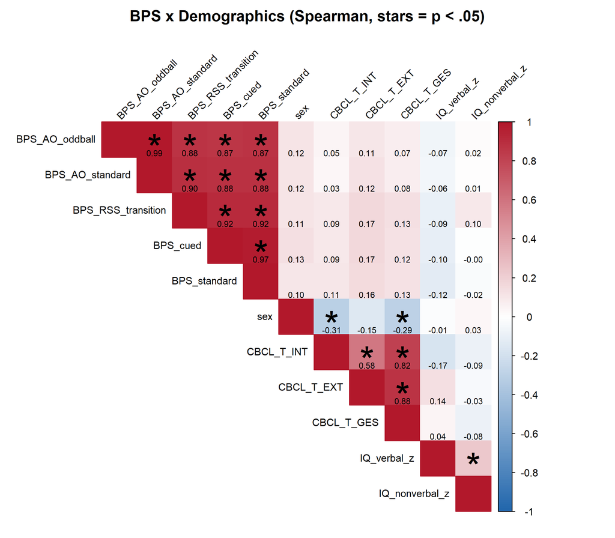

```r
# Setup data
cor_data      <- bps_matrix_d %>%
  mutate(sex = as.numeric(as.factor(sex))) %>%
  select(-id)

bps_demo_cor  <- Hmisc::rcorr(as.matrix(cor_data), type = "spearman")
bps_p <- bps_demo_cor$P
diag(bps_p) <- 1

# 1. Plot without automatic coefficients
corrplot(
  bps_demo_cor$r,
  method      = "color",
  type        = "upper",
  tl.col      = "black",
  tl.srt      = 45,
  tl.cex      = 0.8,
  addCoef.col = NULL,      # Disabled to prevent overlap
  p.mat       = bps_p,
  sig.level   = 0.05,
  insig       = "label_sig",
  col         = colorRampPalette(c("#2166AC", "white", "#B2182B"))(200),
  title       = "BPS x Demographics (Spearman, stars = p < .05)",
  mar         = c(0, 0, 2, 0)
)

# 2. Add coefficients manually with an offset
n_bps <- ncol(bps_demo_cor$r)
for (i in 1:(n_bps-1)) {
  for (j in (i+1):n_bps) {
    text(x = j,
         y = n_bps - i + 1,
         labels = sprintf("%.2f", bps_demo_cor$r[i, j]),
         pos = 1,      # Places text BELOW the center/star
         offset = 0.7, # Adjust this if you want the number higher or lower
         cex = 0.65,
         col = "black")
  }
}
```

## 8.3 Correlations: SEPR x Demographics

[figure not shown]

```r
# Setup data
cor_df        <- df_cor_rpd_raw_d %>%
  mutate(sex = as.numeric(as.factor(sex))) %>%
  select(-id)

sepr_demo_cor <- Hmisc::rcorr(as.matrix(cor_df), type = "spearman")
sepr_p <- sepr_demo_cor$P
diag(sepr_p) <- 1

# 1. Plot without automatic coefficients
corrplot(
  sepr_demo_cor$r,
  method      = "color",
  type        = "upper",
  tl.col      = "black",
  tl.srt      = 45,
  tl.cex      = 0.75,
  addCoef.col = NULL,      # Disabled to prevent overlap
  p.mat       = sepr_p,
  sig.level   = 0.05,
  insig       = "label_sig",
  col         = colorRampPalette(c("#2166AC", "white", "#B2182B"))(200),
  title       = "SEPR x Demographics (Spearman, stars = p < .05)",
  mar         = c(0, 0, 2, 0)
)

# 2. Add coefficients manually with an offset
n_sepr <- ncol(sepr_demo_cor$r)
for (i in 1:(n_sepr-1)) {
  for (j in (i+1):n_sepr) {
    text(x = j,
         y = n_sepr - i + 1,
         labels = sprintf("%.2f", sepr_demo_cor$r[i, j]),
         pos = 1,      # Places text BELOW the center/star
         offset = 0.7, # Adjust as needed
         cex = 0.6,
         col = "black")
  }
}
```